# Analysis Roulette Gambling Study

Philip W. S. Newall, Leonardo Weiss-Cohen, Henrik Singmann, Lukasz Walasek, & Elliot A. Ludvig

Analysis by Henrik Singmann; Script run on 28. July 2020

# Preparation

## Load & Prepare Data

We first load in the data from all participants and transform variables into correct type. We then remove those participants that did not solve enough captchas correctly and only retain some relevant variables. We also prepare remove data from two participants for which for unknown (likely technical) reasons not all data was collected.

Next we load in the data from all bets, create the variables of interest and join with the participants data. Then, we do not forget to set all NAs to zero (participants who did not have betting data are those that skipped betting though have a total bet and win amount of 0). Then we create the oyr DV, proportion of money bet, as follows:
$$\texttt{prop_bet} = \frac{\texttt{amount}}{3 + \texttt{total_win}}$$

The analysis is based on the following number of participants

```
## [1] 1500
```

```
## # A tibble: 3 x 2
##   exp_cond     n
##   <fct>    <int>
## 1 none       499
## 2 white      500
## 3 yellow     501
```

# Payed bonus

Overall bonus paid out was:

```
## [1] 2.8
```

If we split bonus by whether or not participants played, we see clearly that playing leads to less payout:

```
## # A tibble: 2 x 6
##   bet_at_all mean_bonus sd_bonus se_bonus max_bonus min_bonus
##   <chr>           <dbl>    <dbl>    <dbl>     <dbl>     <dbl>
## 1 bet              2.77     2.33   0.0648        30         0
## 2 no bet           3        0      0              3         3
```

# Distribution of DV

Our DV clearly does not look normally distributed.

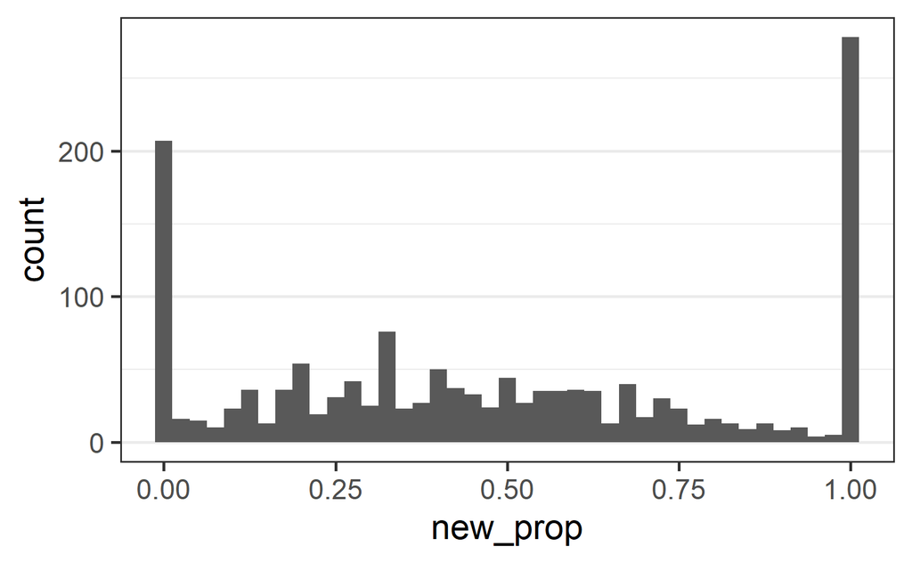

```
## # A tibble: 1 x 3
##   gamble_at_all gamble_everything proportion_bet_rest
##           <dbl>             <dbl>               <dbl>
## 1         0.862             0.212               0.442
```

Binomial confidence or credibility intervals for the probability to gamble at all:

```
##           method    x    n      mean     lower     upper
## 1  agresti-coull 1293 1500 0.8620000 0.8435947 0.8785559
## 2     asymptotic 1293 1500 0.8620000 0.8445460 0.8794540
## 3          bayes 1293 1500 0.8617588 0.8441866 0.8790604
## 4        cloglog 1293 1500 0.8620000 0.8435014 0.8784718
## 5          exact 1293 1500 0.8620000 0.8435037 0.8790656
## 6          logit 1293 1500 0.8620000 0.8436017 0.8785455
## 7         probit 1293 1500 0.8620000 0.8437905 0.8787053
## 8        profile 1293 1500 0.8620000 0.8439340 0.8788308
## 9            lrt 1293 1500 0.8620000 0.8439349 0.8788302
## 10     prop.test 1293 1500 0.8620000 0.8432690 0.8788464
## 11        wilson 1293 1500 0.8620000 0.8436191 0.8785315
```

# Zero-One Inflated Beta Regression

We use a custom parameterization of a zero-one-inflated beta-regression model (see also [here](https://vuorre.netlify.com/post/2019/02/18/analyze-analog-scale-ratings-with-zero-one-inflated-beta-models/)). The likelihood of the model is given by:

$$\begin{align}
f(y) &= (1 - g) & & \text{if } y = 0 \\
f(y) &= g \times e & & \text{if } y = 1 \\
f(y) &= g \times (1 - e) \times \text{Beta}(a,b) & & \text{if } y \notin \{0, 1\} \\
a &= \mu \times \phi \\
b &= (1-\mu) \times \phi
\end{align}$$

Where $1 - g$ is the zero inflation probability, `zipp` is $g$ and reflects the probability to gamble, $e$ is the conditional one-inflation probability (`coi`) or conditional probability to gamble everything (i.e., conditional probability to have a value of one, if one gambles), $\mu$ is the mean of the beta distribution (`Intercept`), and $\phi$ is the precision of the beta distribution (`phi`). As we use `Stan` for modelling, we need to model on the real line and need appropriate link functions. For `\phi` the link is log (inverse is `exp()`), for all other parameters it is logit (inverse is `plogis()`).

We fit this model and add experimental condition as a factor to the three main model parameters (i.e., only the precision parameter is fixed across conditions). The following table provides the overview of the model and all model parameters and show good convergence.

```
##  Family: zoib2
##   Links: mu = logit; phi = log; zipp = logit; coi = logit
## Formula: new_prop ~ exp_cond
##          phi ~ 1
##          zipp ~ exp_cond
##          coi ~ exp_cond
##    Data: part2 (Number of observations: 1500)
## Samples: 4 chains, each with iter = 26000; warmup = 1000; thin = 1;
##          total post-warmup samples = 1e+05
##
## Population-Level Effects:
##                     Estimate Est.Error l-95% CI u-95% CI Rhat Bulk_ESS Tail_ESS
## Intercept              -0.23      0.05    -0.34    -0.13 1.00   149668    76179
## phi_Intercept           1.11      0.04     1.04     1.19 1.00   188488    78137
## zipp_Intercept          1.96      0.14     1.69     2.23 1.00   140453    74727
## coi_Intercept          -1.31      0.12    -1.54    -1.08 1.00   155451    77174
## exp_condwhite           0.08      0.07    -0.06     0.23 1.00   148566    83237
## exp_condyellow          0.15      0.07     0.00     0.29 1.00   145799    84322
## zipp_exp_condwhite     -0.19      0.19    -0.55     0.18 1.00   139533    86972
## zipp_exp_condyellow    -0.17      0.19    -0.53     0.20 1.00   136425    84864
## coi_exp_condwhite      -0.07      0.17    -0.40     0.26 1.00   148168    85135
## coi_exp_condyellow      0.05      0.17    -0.27     0.38 1.00   144756    82084
##
## Samples were drawn using sampling(NUTS). For each parameter, Bulk_ESS
## and Tail_ESS are effective sample size measures, and Rhat is the potential
## scale reduction factor on split chains (at convergence, Rhat = 1).
```

As a visual convergence check, we plot the density and trace plots for the four intercept pasrameters representing the no message condition or the overall mean (for `phi`).

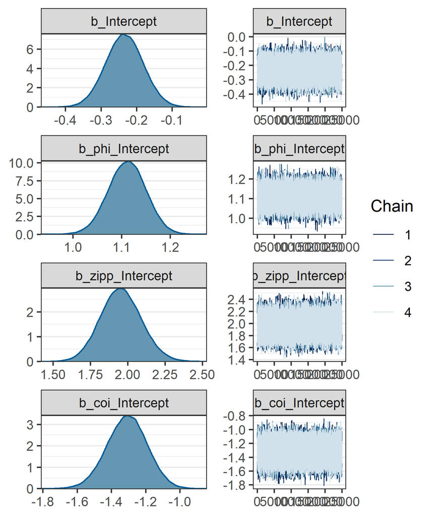

We can also plot the three parameters showing the difference distribution of the yellow message condition from the no messafe condition. These differences are given on the logit scale.

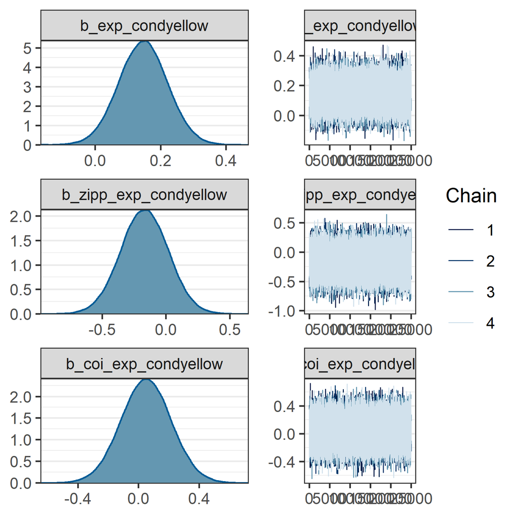

Likewise, we can plot the three parameters showing the difference distribution of the white message condition from the no messafe condition. These differences are given on the logit scale.

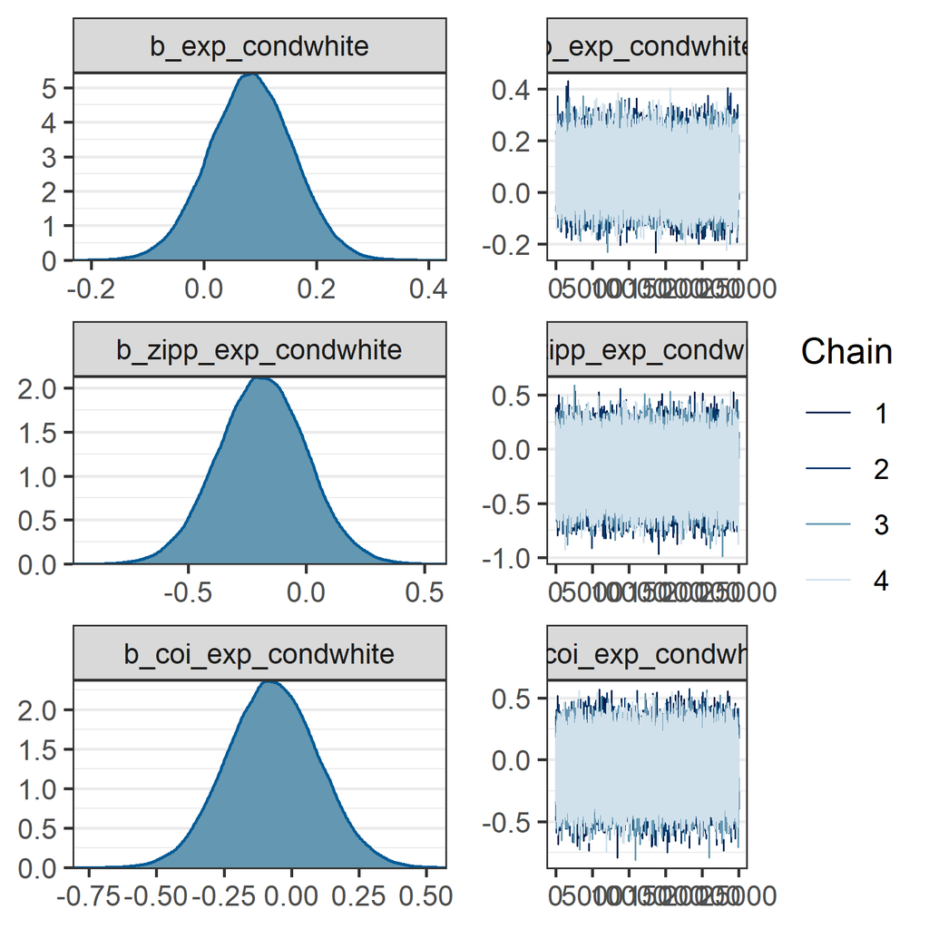

The model does not have any obvious problems, even without priors for the condition specific effects.

## Posterior Predictive Checks

As expected the synthetic data generated from the model looks a lot like the actual data. This suggests that the model is adequate for the data.

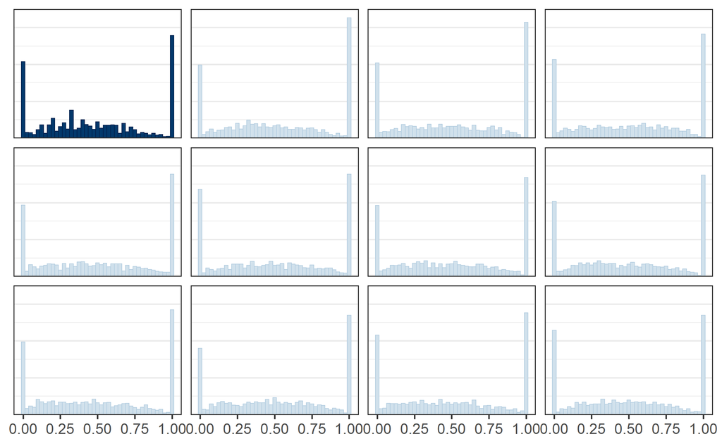

## Model Estimates

We first give the table showing the posterior means and 95% CIs.

```
## # A tibble: 9 x 8
## # Groups:   parameter [3]
##   parameter          condition estimate .lower .upper .width .point .interval
##   <fct>              <chr>        <dbl>  <dbl>  <dbl>  <dbl> <chr>  <chr>
## 1 Gamble at all?     None         0.875  0.845  0.903   0.95 mean   qi
## 2 Gamble at all?     White        0.853  0.821  0.883   0.95 mean   qi
## 3 Gamble at all?     Yellow       0.856  0.824  0.885   0.95 mean   qi
## 4 Gamble everything? None         0.213  0.176  0.253   0.95 mean   qi
## 5 Gamble everything? White        0.202  0.165  0.241   0.95 mean   qi
## 6 Gamble everything? Yellow       0.222  0.184  0.262   0.95 mean   qi
## 7 Proportion bet?    None         0.442  0.416  0.467   0.95 mean   qi
## 8 Proportion bet?    White        0.463  0.437  0.488   0.95 mean   qi
## 9 Proportion bet?    Yellow       0.478  0.452  0.504   0.95 mean   qi
```

For the zero-one inflated components, we can compare the model estimates with the data. Not unsurprisingly, they match quite well.

```
## # A tibble: 3 x 3
##   exp_cond gamble_at_all gamble_everything
##   <fct>            <dbl>             <dbl>
## 1 none             0.876             0.213
## 2 white            0.854             0.201
## 3 yellow           0.856             0.221
```

The following is the main results figure on the level of the message conditions.

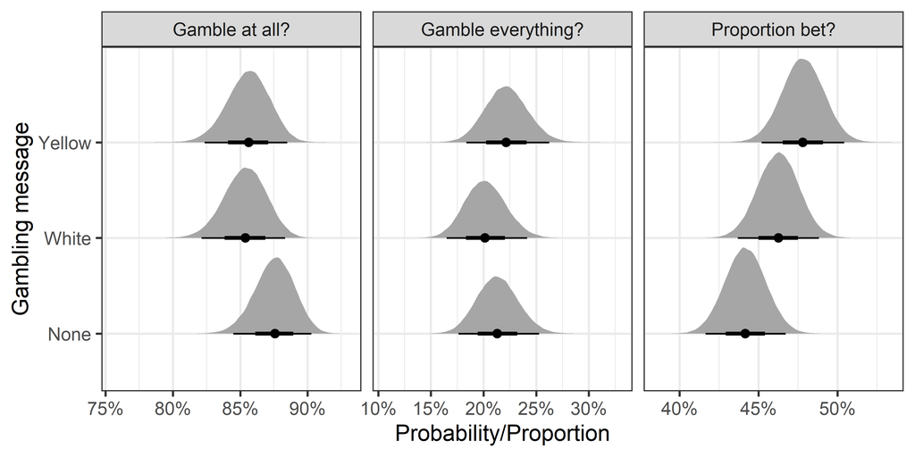

## Difference distribution versus no message condition

We can also focus and look at the difference distributions from the no message condition (i.e., we do not show the “Yellow versus White” comparison, but all below are against no message condition).

```
## # A tibble: 6 x 8
## # Groups:   parameter [3]
##   parameter          condition estimate     .lower .upper .width .point .interval
##   <fct>              <fct>        <dbl>      <dbl>  <dbl>  <dbl> <chr>  <chr>
## 1 Gamble at all?     White     -0.0218  -0.0643    0.0209   0.95 mean   qi
## 2 Gamble at all?     Yellow    -0.0194  -0.0616    0.0227   0.95 mean   qi
## 3 Gamble everything? White     -0.0114  -0.0652    0.0431   0.95 mean   qi
## 4 Gamble everything? Yellow     0.00853 -0.0466    0.0639   0.95 mean   qi
## 5 Proportion bet?    White      0.0208  -0.0154    0.0568   0.95 mean   qi
## 6 Proportion bet?    Yellow     0.0364   0.0000330 0.0727   0.95 mean   qi
```

Same as a figure.

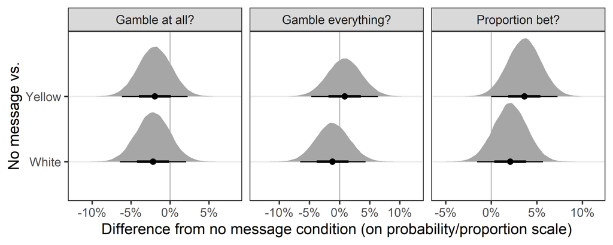

## All Difference Distributions

For reference, we below include another plot of the difference distributions but this time include the distribution comparing the Yellow versus White warning message comparison as well.

```
## # A tibble: 9 x 8
## # Groups:   parameter [3]
##   parameter          condition      estimate     .lower .upper .width .point .interval
##   <fct>              <fct>             <dbl>      <dbl>  <dbl>  <dbl> <chr>  <chr>
## 1 Gamble at all?     Yellow - White  0.00233 -0.0415    0.0459   0.95 mean   qi
## 2 Gamble at all?     White - None   -0.0218  -0.0643    0.0209   0.95 mean   qi
## 3 Gamble at all?     Yellow - None  -0.0194  -0.0616    0.0227   0.95 mean   qi
## 4 Gamble everything? Yellow - White  0.0199  -0.0350    0.0750   0.95 mean   qi
## 5 Gamble everything? White - None   -0.0114  -0.0652    0.0431   0.95 mean   qi
## 6 Gamble everything? Yellow - None   0.00853 -0.0466    0.0639   0.95 mean   qi
## 7 Proportion bet?    Yellow - White  0.0156  -0.0212    0.0521   0.95 mean   qi
## 8 Proportion bet?    White - None    0.0208  -0.0154    0.0568   0.95 mean   qi
## 9 Proportion bet?    Yellow - None   0.0364   0.0000330 0.0727   0.95 mean   qi
```

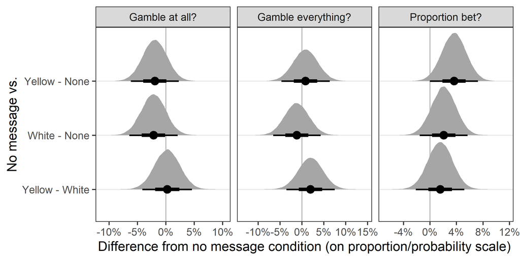

## All Difference Distributions with Possible Priors

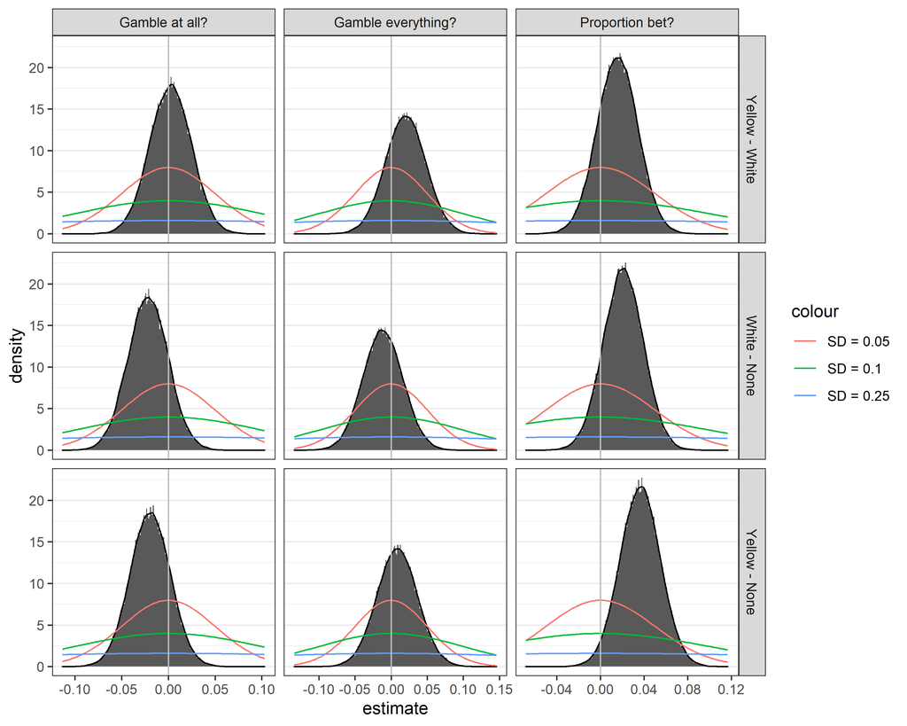

## Control versus Warning Label

We now look at the data but aggregate both gambling message conditions into one (i.e., we only have no message versus message).

```
## # A tibble: 6 x 8
## # Groups:   parameter [3]
##   parameter          condition estimate .lower .upper .width .point .interval
##   <fct>              <chr>        <dbl>  <dbl>  <dbl>  <dbl> <chr>  <chr>
## 1 Gamble at all?     control      0.875  0.845  0.903   0.95 mean   qi
## 2 Gamble at all?     warning      0.855  0.833  0.876   0.95 mean   qi
## 3 Gamble everything? control      0.213  0.176  0.253   0.95 mean   qi
## 4 Gamble everything? warning      0.211  0.185  0.239   0.95 mean   qi
## 5 Proportion bet?    control      0.442  0.416  0.467   0.95 mean   qi
## 6 Proportion bet?    warning      0.470  0.452  0.489   0.95 mean   qi
```

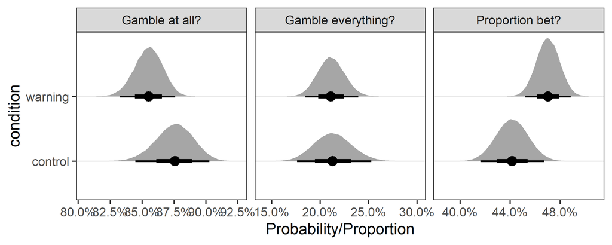

[output not shown]

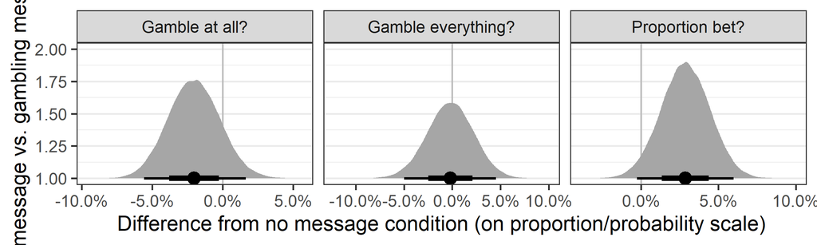

# Model With Covariates

The covariates do not differ between conditions (strong BF evidence for the null).

```
## Bayes factor analysis
## --------------
## [1] Intercept only : 47.38753 ±0.03%
##
## Against denominator:
##   pgsi ~ exp_cond
## ---
## Bayes factor type: BFlinearModel, JZS
```

```
## Bayes factor analysis
## --------------
## [1] Intercept only : 32.31008 ±0.03%
##
## Against denominator:
##   motives ~ exp_cond
## ---
## Bayes factor type: BFlinearModel, JZS
```

The following table shows mean and SDs of the covariates per group.

```
## # A tibble: 3 x 5
##   exp_cond pgsi_mean pgsi_sd motives_mean motives_sd
##   <fct>        <dbl>   <dbl>        <dbl>      <dbl>
## 1 none          3.03    4.83         6.01       3.91
## 2 white         2.66    4.30         6.27       3.98
## 3 yellow        2.70    4.40         5.86       3.89
```

## Model with Main Effects

```
##  Family: zoib2
##   Links: mu = logit; phi = log; zipp = logit; coi = logit
## Formula: new_prop ~ exp_cond + pgsi_c + motives_c
##          phi ~ 1
##          zipp ~ exp_cond + pgsi_c + motives_c
##          coi ~ exp_cond + pgsi_c + motives_c
##    Data: part2 (Number of observations: 1500)
## Samples: 4 chains, each with iter = 26000; warmup = 1000; thin = 1;
##          total post-warmup samples = 1e+05
##
## Population-Level Effects:
##                     Estimate Est.Error l-95% CI u-95% CI Rhat Bulk_ESS Tail_ESS
## Intercept              -0.23      0.05    -0.34    -0.13 1.00   137264    79419
## phi_Intercept           1.12      0.04     1.04     1.20 1.00   195173    76707
## zipp_Intercept          2.08      0.14     1.80     2.36 1.00   130576    80893
## coi_Intercept          -1.37      0.12    -1.60    -1.14 1.00   137274    80350
## exp_condwhite           0.08      0.07    -0.07     0.23 1.00   134442    88120
## exp_condyellow          0.15      0.07     0.00     0.29 1.00   132740    86367
## pgsi_c                  0.01      0.01    -0.01     0.02 1.00   169765    84376
## motives_c               0.02      0.01     0.00     0.04 1.00   171755    83729
## zipp_exp_condwhite     -0.23      0.19    -0.60     0.14 1.00   136926    88963
## zipp_exp_condyellow    -0.16      0.19    -0.53     0.21 1.00   136948    86754
## zipp_pgsi_c            -0.01      0.02    -0.05     0.03 1.00   157548    78763
## zipp_motives_c          0.15      0.02     0.10     0.19 1.00   138593    83935
## coi_exp_condwhite      -0.05      0.17    -0.38     0.29 1.00   137691    86016
## coi_exp_condyellow      0.07      0.17    -0.25     0.40 1.00   138616    86998
## coi_pgsi_c              0.07      0.01     0.04     0.09 1.00   162048    83318
## coi_motives_c           0.02      0.02    -0.02     0.05 1.00   156239    84186
##
## Samples were drawn using sampling(NUTS). For each parameter, Bulk_ESS
## and Tail_ESS are effective sample size measures, and Rhat is the potential
## scale reduction factor on split chains (at convergence, Rhat = 1).
```

As a visual convergence check, we plot the density and trace plots for the four intercept pasrameters representing the no message condition or the overall mean (for `phi`).

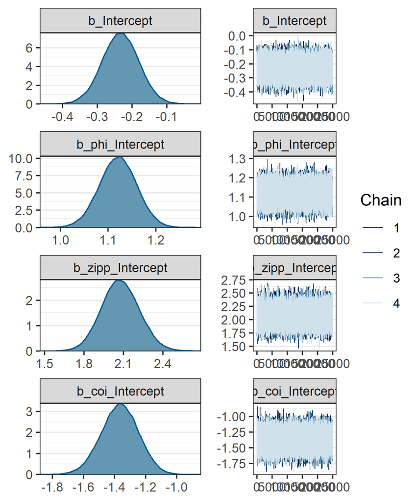

We can also plot the three parameters showing the difference distribution of the yellow message condition from the no messafe condition. These differences are given on the logit scale.

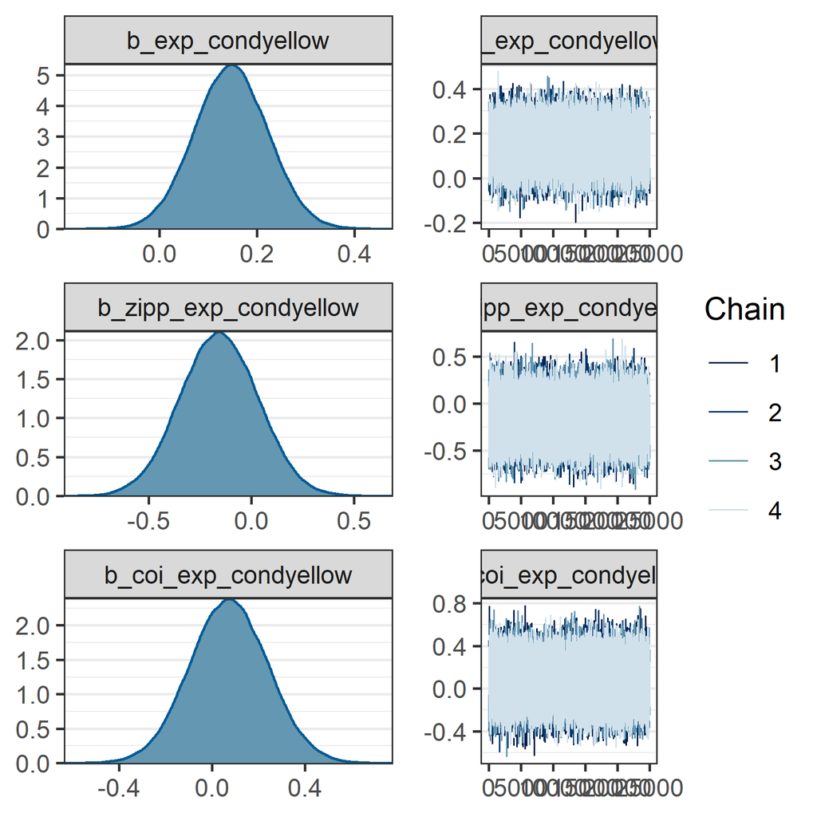

Likewise, we can plot the three parameters showing the difference distribution of the white message condition from the no messafe condition. These differences are given on the logit scale.

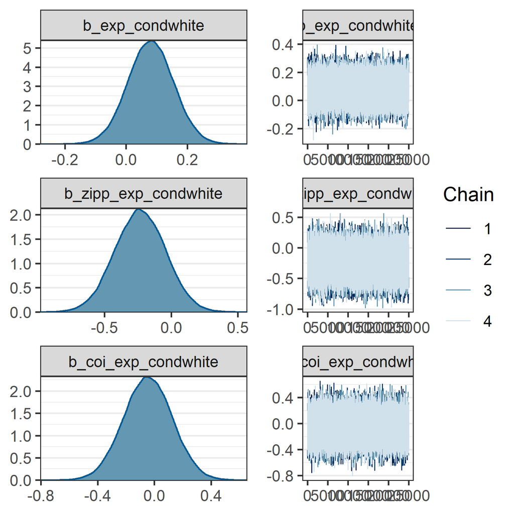

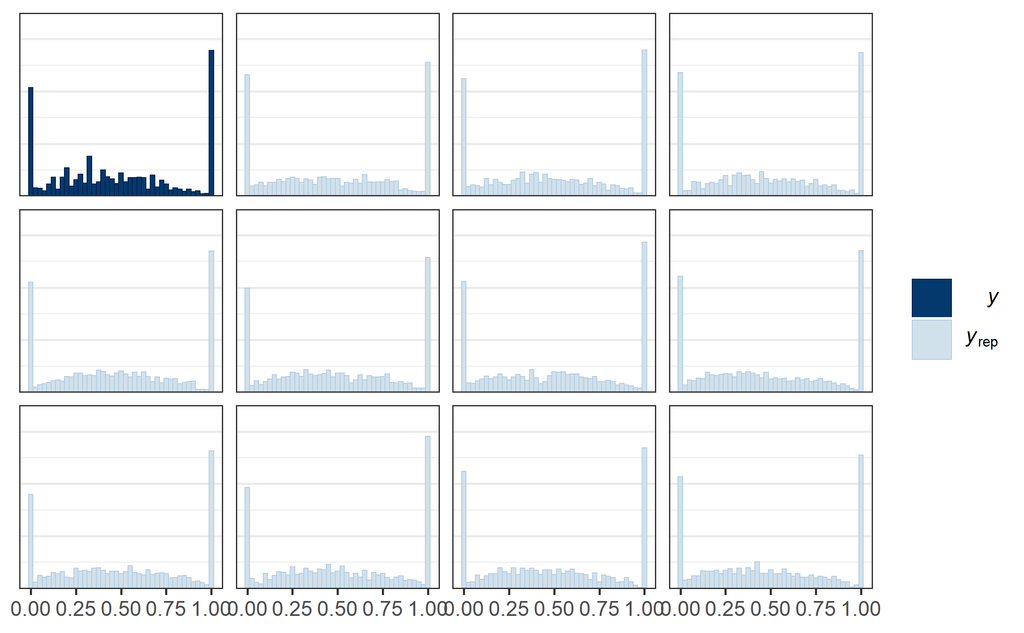

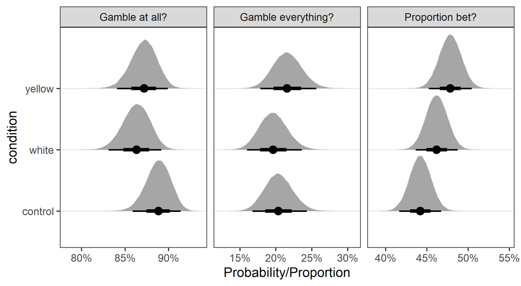

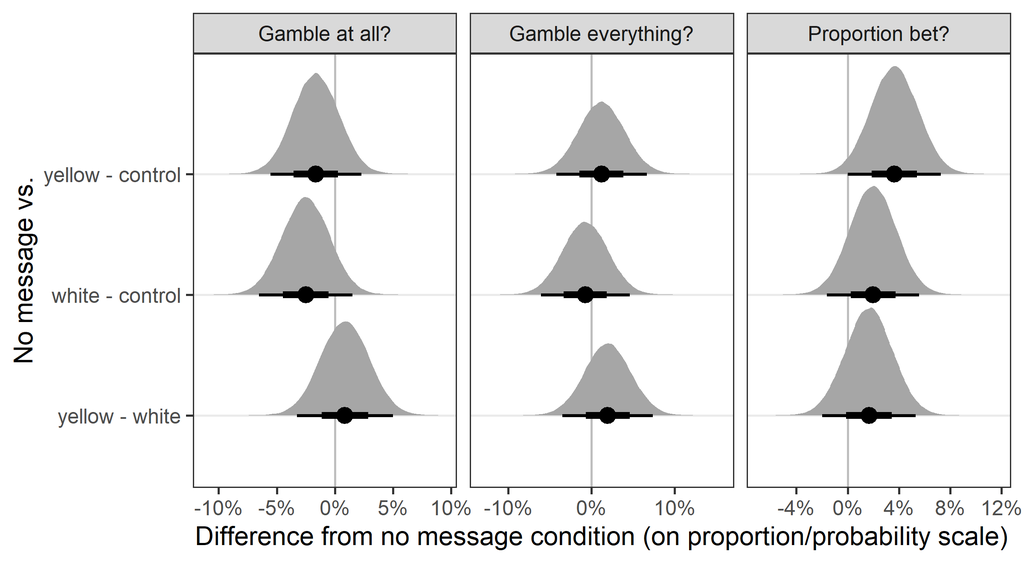

### Plot of Relationships and BANOVA

The figure below provides an alternative visualisation of the relationships between covariates and betting behaviour. In particular, participants were categorized into one of three experimental betting behavior groups: participants who did not bet at all (“none”, 14% of participants), participants who bet some of their money (68% of participants), and participants who bet “all” of their money (18%). For both gambling scales we see a positive relationship between the betting behavior group and the gambling score. Participants who bet more have on average higher scores on the two gambling scales.

```
##
##      none      some       all
## 0.1380000 0.6793333 0.1826667
```

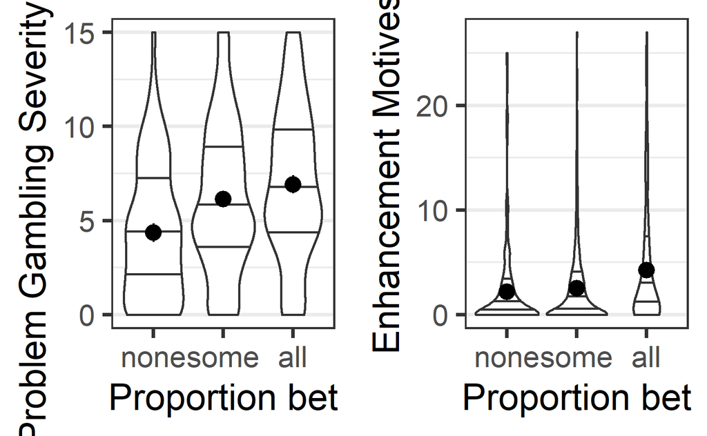

This is supported by Bayesian ANOVAs with Bayes factors of over 400,000 for the effect of betting behavior group on the gambing scale scores. However, this effect was not moderated by gambling message condition. In particular, there was evidence for the absence of both a main effect of gambling message condition and an interaction of gambling message condition with betting behaviour group for both gambling scale scores (Bayes factors for the null > 25).

```
## Bayes factor analysis
## --------------
## [1] exp_cond                                    : 0.0211026 ±0.03%
## [2] gamble_cat                                  : 474496    ±0.03%
## [3] exp_cond + gamble_cat                       : 9116.45   ±1.19%
## [4] exp_cond + gamble_cat + exp_cond:gamble_cat : 41.46294  ±1.46%
##
## Against denominator:
##   Intercept only
## ---
## Bayes factor type: BFlinearModel, JZS
```

```
##             denominator
## numerator    exp_cond gamble_cat exp_cond + gamble_cat exp_cond + gamble_cat + exp_cond:gamble_cat
##   gamble_cat 22485192          1              52.04832                                    11443.86
```

```
## Bayes factor analysis
## --------------
## [1] exp_cond                                    : 0.0309501  ±0.03%
## [2] gamble_cat                                  : 1843612186 ±0.03%
## [3] exp_cond + gamble_cat                       : 71024227   ±1.16%
## [4] exp_cond + gamble_cat + exp_cond:gamble_cat : 1009814    ±1.4%
##
## Against denominator:
##   Intercept only
## ---
## Bayes factor type: BFlinearModel, JZS
```

```
##             denominator
## numerator       exp_cond gamble_cat exp_cond + gamble_cat exp_cond + gamble_cat + exp_cond:gamble_cat
##   gamble_cat 59567253708          1              25.95751                                    1825.695
```

## Model With Interactions

```
##  Family: zoib2
##   Links: mu = logit; phi = log; zipp = logit; coi = logit
## Formula: new_prop ~ exp_cond * (pgsi_c + motives_c)
##          phi ~ 1
##          zipp ~ exp_cond * (pgsi_c + motives_c)
##          coi ~ exp_cond * (pgsi_c + motives_c)
##    Data: part2 (Number of observations: 1500)
## Samples: 4 chains, each with iter = 26000; warmup = 1000; thin = 1;
##          total post-warmup samples = 1e+05
##
## Population-Level Effects:
##                               Estimate Est.Error l-95% CI u-95% CI Rhat Bulk_ESS Tail_ESS
## Intercept                        -0.24      0.05    -0.34    -0.13 1.00   158342    76097
## phi_Intercept                     1.13      0.04     1.05     1.20 1.00   184954    74433
## zipp_Intercept                    2.16      0.16     1.85     2.49 1.00    86130    70226
## coi_Intercept                    -1.38      0.12    -1.63    -1.15 1.00   134985    78058
## exp_condwhite                     0.09      0.08    -0.06     0.24 1.00   145747    81616
## exp_condyellow                    0.16      0.08     0.01     0.30 1.00   148752    84007
## pgsi_c                           -0.01      0.01    -0.04     0.01 1.00    84979    79829
## motives_c                         0.04      0.01     0.01     0.07 1.00    79388    78932
## exp_condwhite:pgsi_c              0.04      0.02     0.00     0.08 1.00    99695    81421
## exp_condyellow:pgsi_c             0.03      0.02    -0.00     0.07 1.00    98713    83957
## exp_condwhite:motives_c          -0.02      0.02    -0.06     0.02 1.00    87967    83521
## exp_condyellow:motives_c         -0.04      0.02    -0.08     0.00 1.00    89525    82219
## zipp_exp_condwhite               -0.35      0.21    -0.76     0.05 1.00    98841    80318
## zipp_exp_condyellow              -0.17      0.22    -0.61     0.26 1.00    95718    78198
## zipp_pgsi_c                      -0.03      0.03    -0.09     0.03 1.00    76351    74195
## zipp_motives_c                    0.19      0.05     0.11     0.29 1.00    61798    66661
## zipp_exp_condwhite:pgsi_c         0.04      0.05    -0.06     0.13 1.00    91370    79221
## zipp_exp_condyellow:pgsi_c        0.04      0.05    -0.06     0.14 1.00    91206    75879
## zipp_exp_condwhite:motives_c     -0.10      0.06    -0.22     0.01 1.00    69073    75699
## zipp_exp_condyellow:motives_c    -0.02      0.06    -0.14     0.10 1.00    69843    76046
## coi_exp_condwhite                -0.03      0.18    -0.37     0.31 1.00   133825    82024
## coi_exp_condyellow                0.08      0.17    -0.25     0.42 1.00   132528    81794
## coi_pgsi_c                        0.05      0.02     0.00     0.09 1.00    84270    81113
## coi_motives_c                     0.06      0.03    -0.01     0.12 1.00    75499    77397
## coi_exp_condwhite:pgsi_c          0.01      0.04    -0.06     0.08 1.00    96565    82520
## coi_exp_condyellow:pgsi_c         0.05      0.04    -0.02     0.12 1.00    93175    83688
## coi_exp_condwhite:motives_c      -0.04      0.05    -0.13     0.05 1.00    84410    79773
## coi_exp_condyellow:motives_c     -0.09      0.05    -0.18     0.00 1.00    85118    81688
##
## Samples were drawn using sampling(NUTS). For each parameter, Bulk_ESS
## and Tail_ESS are effective sample size measures, and Rhat is the potential
## scale reduction factor on split chains (at convergence, Rhat = 1).
```

As a visual convergence check, we plot the density and trace plots for the four intercept parameters representing the no message condition or the overall mean (for `phi`).

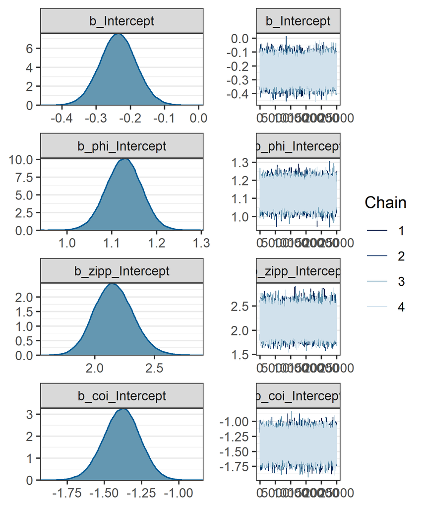

We can also plot the three parameters showing the difference distribution of the yellow message condition from the no messafe condition. These differences are given on the logit scale.

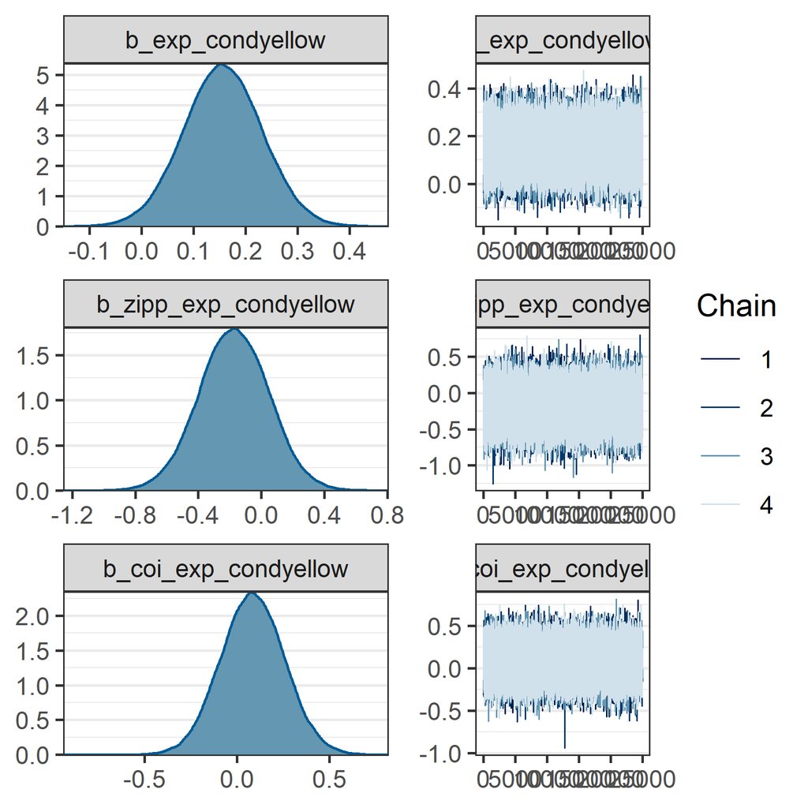

Likewise, we can plot the three parameters showing the difference distribution of the white message condition from the no messafe condition. These differences are given on the logit scale.

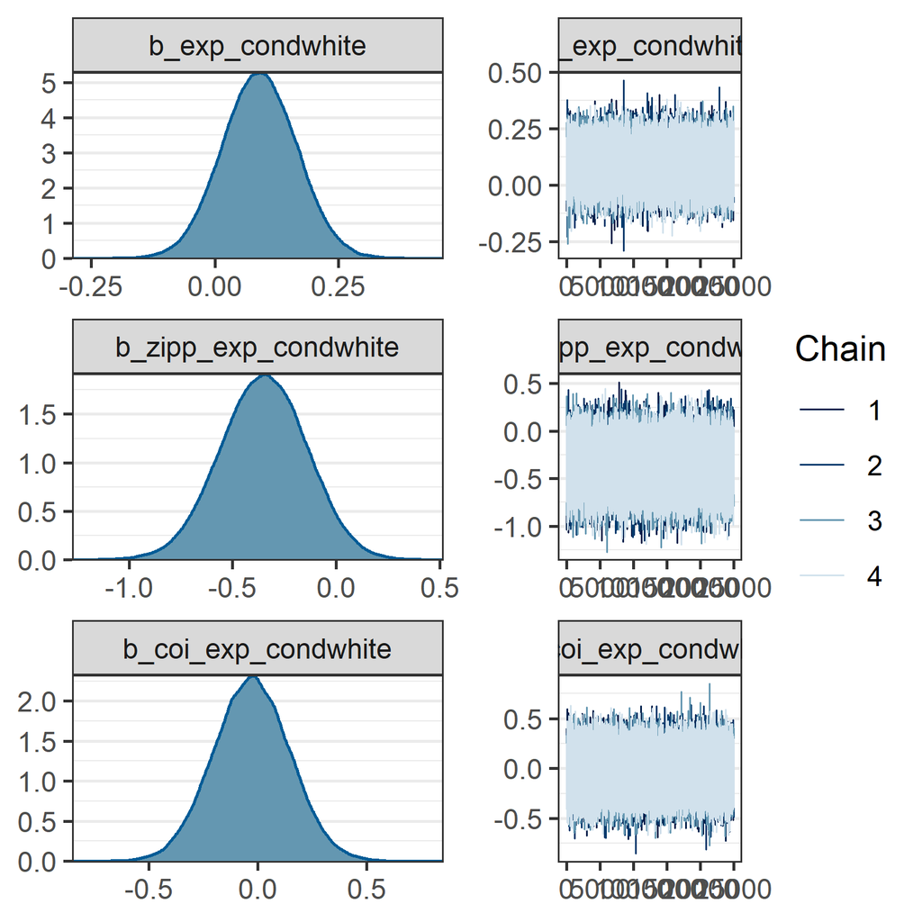

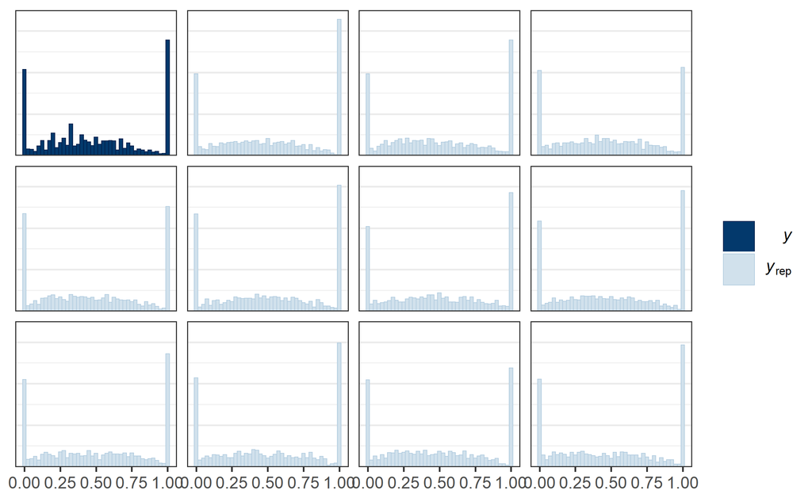

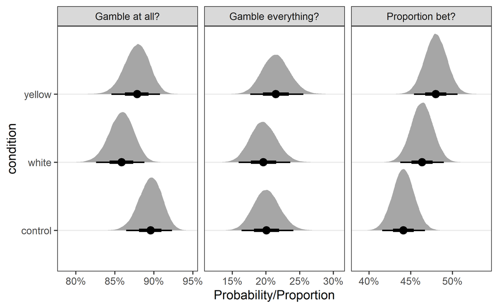

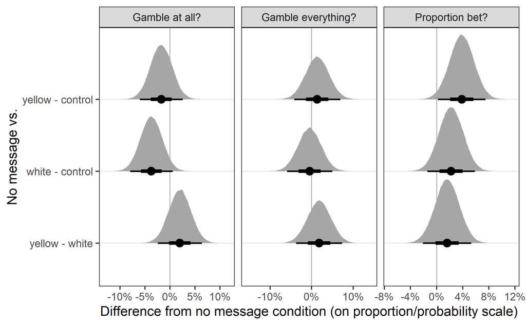

# Riskiness of Bets

Do either of the warning labels affect the riskiness of bets chosen in the roulette? Different bets come with different potential payoffs in roulette. If £1 is bet, then this can provide a total payoff of between £2 (e.g., bets on red or black) and £36 (bets on a single number). These numbers, 2 and 36, are the decimal odds for these two bets, representing the total potential payoff Additionally, gamblers can place multiple bets per spin, (e.g., betting £0.50 on red and £0.50 on 7). Since the number 7 is a red colour, the bet on 7 can only win if the first bet on red also wins. Multiple bets per spin can either be placed in a way that accentuates risk, as in this example, or in a way that hedges risk (for example, a bet on black added to the bet on 7, or betting on reds and blacks together). The purpose of this exploratory analysis is to see if either warning label affects risk taking.

Following our pre-registration we have measures the amount of risk taken by looking at the variance of the decimal odds for each number in the roulette table. It will measure the concentration of the bet, with more risk represented by more concentrated bets (e.g., betting on a single number), and lower risk represented by more spread bets (e.g., betting on reds, betting on evens). For example, if a participant places a bet on number 7, the decimal odds for that number is 36 (36 times the amount bet if the roulette stops on the number 7). If a participant places a bet on red, then every red number on the table gets a decimal odd of 2 (the participant will win twice the amount bet if the roulette stops on any red number). In order to calculate the proposed risk variable, we will also assign decimal odds of zero for the numbers in which participants did not bet (since they win zero times the amount bet if the roulette stops on those numbers). In the two examples above, every number except 7 will be assigned zero, and every non-red number will be assigned zero, respectively. The risk variable will be the variance of the array of decimal odds for every number on the roulette table, taking into account the bets the participant has placed, and including zeroes for non-winning numbers. The value of this risk variable can range between 0.03 and 35.03. The value cannot be zero in our task because participants are not able to bet the same amount across all numbers including the zero due to the limitations in the values of the available tokens and total bet amounts. Higher numbers indicate more risk taking (with the highest, 35.03, associated with concentrating the bet on a single number). Lower numbers indicate lower risk taking (with the lowest, 0.03, associated with spreading the bet across every red and black number, excluding zero).

The following plot shows the distribution of this variable after aggregating within participants. The left plot shows the original variable on the scale from 0.03 to 35.03. The middle plot shows the variable after dividing by 36 so that the variable ranges from just above 0 to just below 1. The right plot shows the variable after subtracting 0.03 and dividing by 35 so that the smallest value is mapped to 0 and the largest value is mapped to 1.

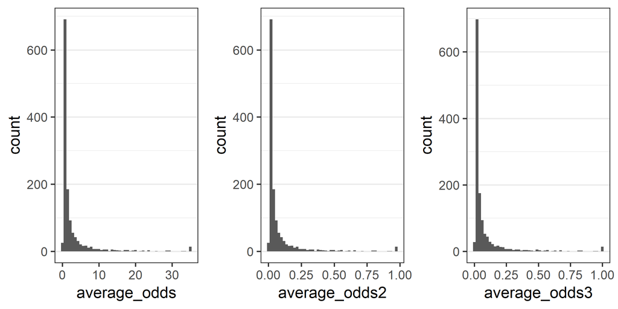

## Beta Regression

We first analyse the data with a beta-regression model. For this, the data needs to be between 0 and 1, but exclude exactly 0 and 1. Consequently, we use the transformation shown above in the middle panel. As before, we fit the data and allow for an effect of gambling message.

The model does not show any obvious problems. In addition, we can see that the 95%-CIs for the gambling message specific effects both include 0.

```
##  Family: beta
##   Links: mu = logit; phi = log
## Formula: average_odds2 ~ exp_cond
##          phi ~ 1
##    Data: bets_av (Number of observations: 1293)
## Samples: 4 chains, each with iter = 2000; warmup = 1000; thin = 1;
##          total post-warmup samples = 4000
##
## Population-Level Effects:
##                Estimate Est.Error l-95% CI u-95% CI Rhat Bulk_ESS Tail_ESS
## Intercept         -2.09      0.05    -2.18    -1.99 1.00     2755     2690
## phi_Intercept      1.77      0.04     1.68     1.85 1.00     2850     2695
## exp_condwhite     -0.03      0.06    -0.16     0.10 1.00     2926     2830
## exp_condyellow    -0.08      0.06    -0.21     0.04 1.00     2952     2955
##
## Samples were drawn using sampling(NUTS). For each parameter, Bulk_ESS
## and Tail_ESS are effective sample size measures, and Rhat is the potential
## scale reduction factor on split chains (at convergence, Rhat = 1).
```

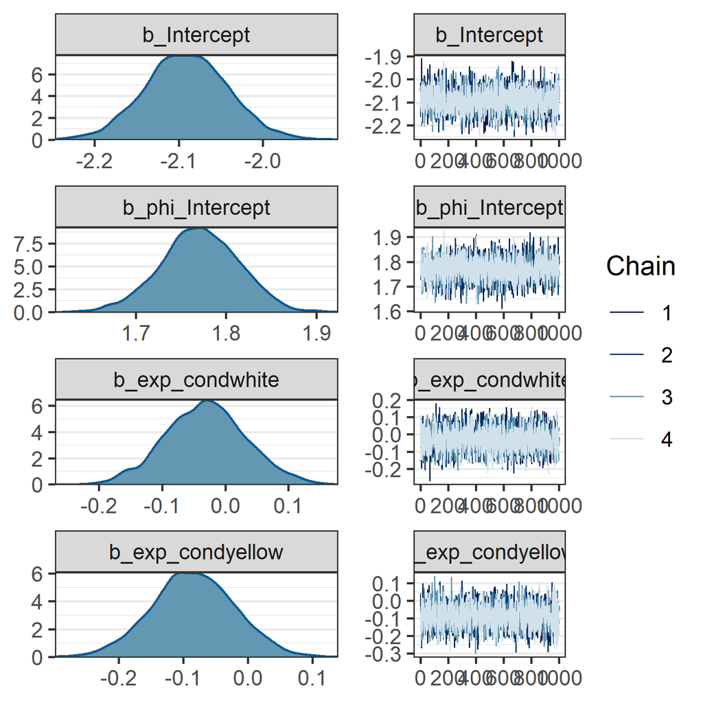

The posterior predictive distribution shows some problems, but at least the shape of the synthetic data is similar to the distribution of the actual data (posterior predictive distributions of a model assuming a Gaussian response distribution was considerably worse and is therefore not incldued here).

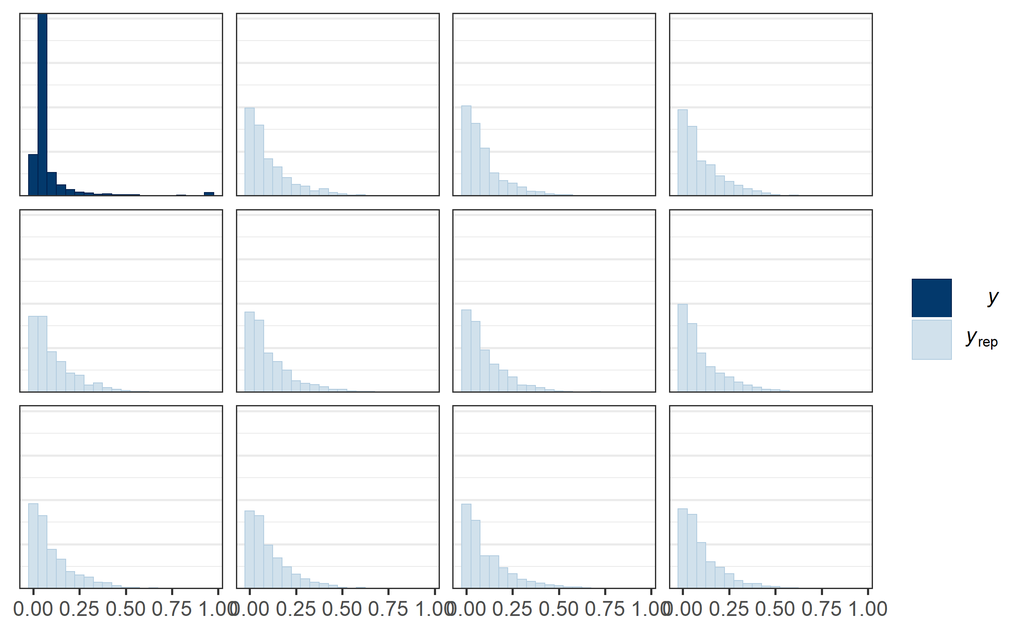

The following tables show the average riskiness per warning label and differences from the no warning message group on the fitted scale, i.e., the (0, 1) scale used for the beta regression.

```
## # A tibble: 3 x 7
##   condition estimate .lower .upper .width .point .interval
##   <chr>        <dbl>  <dbl>  <dbl>  <dbl> <chr>  <chr>
## 1 None         0.110 0.101   0.120   0.95 mean   qi
## 2 White        0.107 0.0978  0.117   0.95 mean   qi
## 3 Yellow       0.102 0.0935  0.111   0.95 mean   qi
```

```
## # A tibble: 2 x 7
##   condition estimate  .lower  .upper .width .point .interval
##   <fct>        <dbl>   <dbl>   <dbl>  <dbl> <chr>  <chr>
## 1 White     -0.00299 -0.0151 0.00943   0.95 mean   qi
## 2 Yellow    -0.00800 -0.0200 0.00368   0.95 mean   qi
```

The following plot shows the distribution of the posteriors (left) and difference from the no message gorup (right). Both of these variables are back-transformed on the original scale from 0.03 to 35.03.

```
## Warning: 'geom_halfeyeh' is deprecated.
## Use 'stat_halfeye' instead.
## See help("Deprecated") and help("tidybayes-deprecated").
```

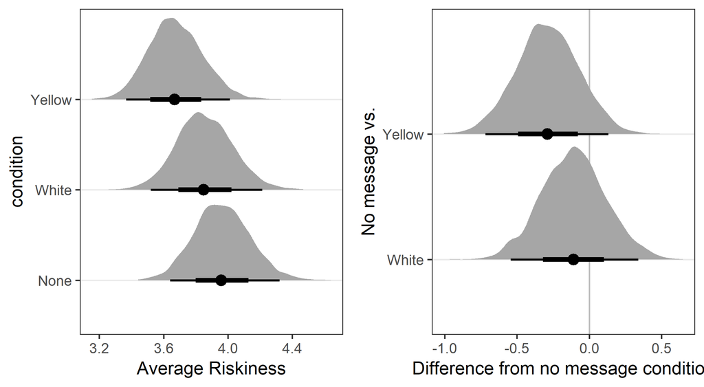

As is clear from the plots, there is no evidence for a difference. Furthermore, there is some evidence for no difference for the white message, but only ambigous evidence for the yellow message.

## Zero-One Inflated Beta-Regression Model

We also attempt to fit a zero-one inflated beta regression model to the data transformed onto the [0, 1] scale (i.e., right panel in the histograms above). Note that this model uses the `brms` default parameterisation for ZOIBR models and not the custom ones used above.

This model also does not show any effect of message condition as none of the effects involving message condition (i.e., variable names containing `exp`) excludes 0 from theit 95% CI.

```
##  Family: zero_one_inflated_beta
##   Links: mu = logit; phi = log; zoi = logit; coi = logit
## Formula: average_odds3 ~ exp_cond
##          phi ~ 1
##          zoi ~ exp_cond
##          coi ~ exp_cond
##    Data: bets_av (Number of observations: 1293)
## Samples: 4 chains, each with iter = 2000; warmup = 1000; thin = 1;
##          total post-warmup samples = 4000
##
## Population-Level Effects:
##                    Estimate Est.Error l-95% CI u-95% CI Rhat Bulk_ESS Tail_ESS
## Intercept             -2.39      0.04    -2.47    -2.30 1.00     3714     2675
## phi_Intercept          2.37      0.04     2.29     2.46 1.00     3693     3068
## zoi_Intercept         -4.14      0.39    -4.95    -3.43 1.00     3753     2718
## coi_Intercept          0.86      0.88    -0.76     2.76 1.00     4633     3307
## exp_condwhite         -0.05      0.06    -0.17     0.06 1.00     3925     2914
## exp_condyellow        -0.09      0.06    -0.20     0.02 1.00     4056     2970
## zoi_exp_condwhite     -0.32      0.61    -1.57     0.83 1.00     3441     2839
## zoi_exp_condyellow     0.04      0.54    -1.04     1.08 1.00     3654     2258
## coi_exp_condwhite      4.39      3.48    -0.57    12.88 1.00     2117     1458
## coi_exp_condyellow    -0.69      1.19    -3.10     1.60 1.00     4548     2439
##
## Samples were drawn using sampling(NUTS). For each parameter, Bulk_ESS
## and Tail_ESS are effective sample size measures, and Rhat is the potential
## scale reduction factor on split chains (at convergence, Rhat = 1).
```

Furthermore, the posterior predictive distribution is not actually better. Hence, we prefer the beta regression model above.

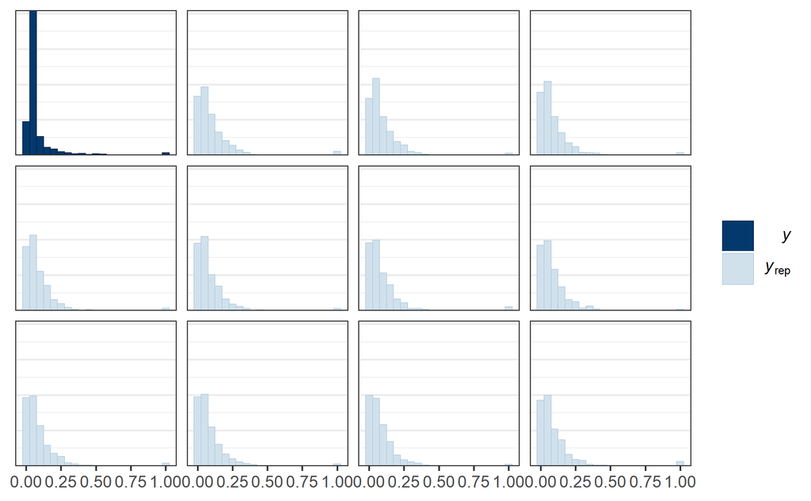